# Homework week_05 day_1

# Q1 - load and view data

```r
library(tidyverse)
library(CodeClanData)
backpack_data <- backpack

names(backpack_data)
```

```
## [1] "backpack_weight" "body_weight"     "ratio"           "back_problems"
## [5] "major"           "year"            "sex"             "status"
## [9] "units"
```

# Q2 - What is the distribution of backpack weights that students are carrying?

The graph shows the weight carried by the number of students.

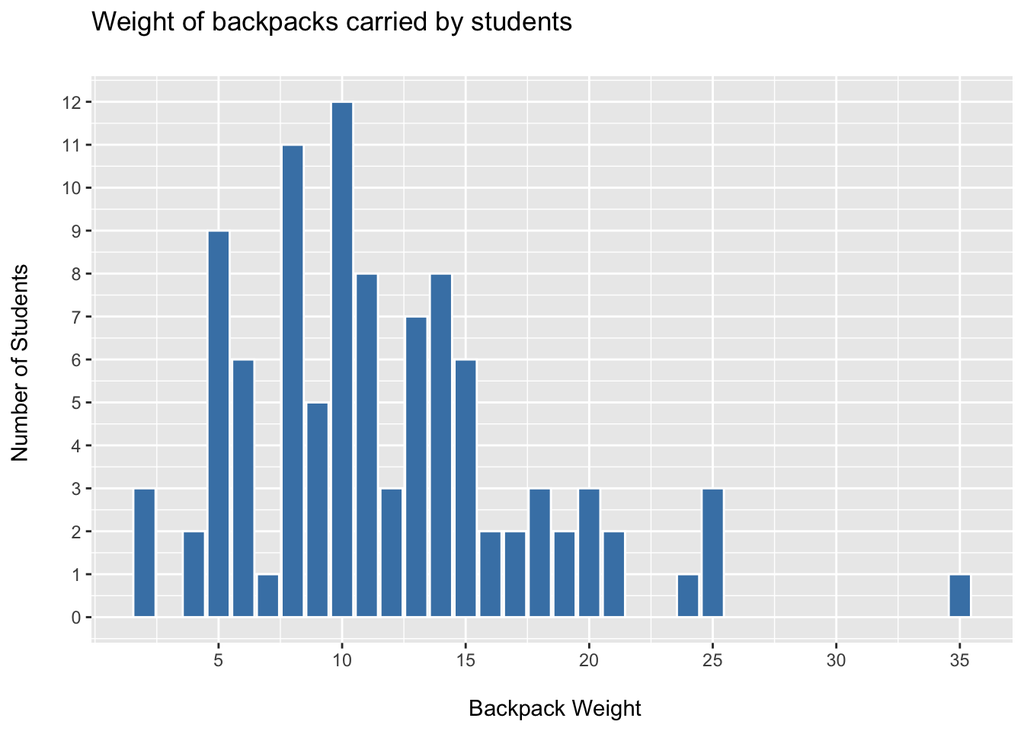

```r
ggplot(backpack_data) +
  aes(x = backpack_weight) +
  geom_bar(col = "white", fill = "steel blue") +
  scale_x_continuous(breaks = c(5, 10, 15, 20, 25,  30, 35)) +
  scale_y_continuous(breaks = 0:13) +
  labs(
    x = "\n Backpack Weight",
    y = "Number of Students \n",
    title = "Weight of backpacks carried by students \n"
  )
```

# Q3 - Are there differences in backpack weight between sex?

- Note that there are more females than males in the data (55 Female, 45 Male)
- The most common backpack weight for a female student is 10, for a male student it is 11
- Need to check how to alter the title of the legend

## Check numbers:

```r
backpack_data %>%
  group_by(sex) %>%
  summarise(count = n())
```

| sex | count |
| --- | --- |
| Female | 55 |
| Male | 45 |

## Plot data:

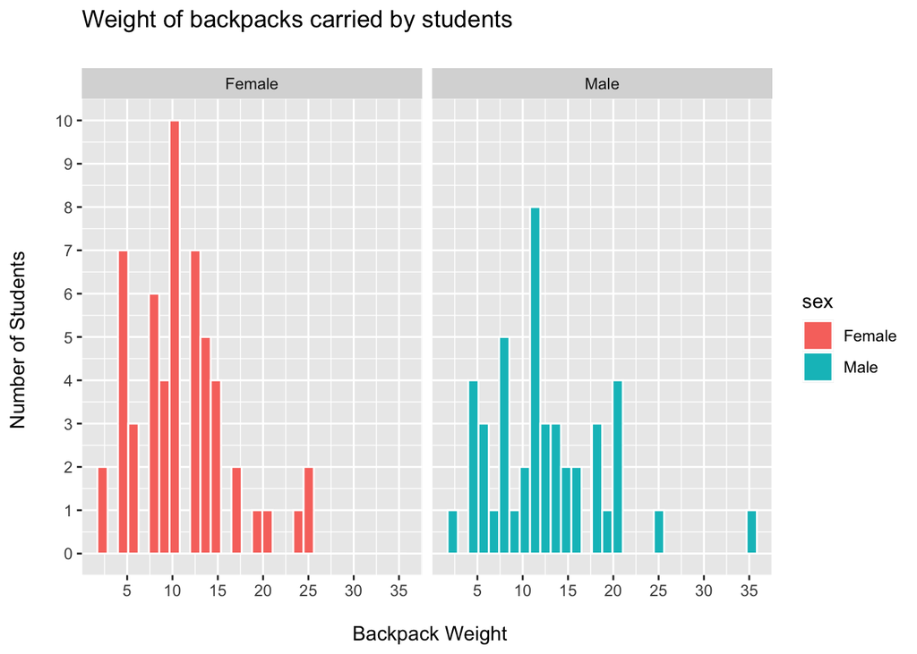

```r
ggplot(backpack_data) +
  aes(x = backpack_weight, fill = sex) +
  geom_histogram(col = "white") +
  scale_x_continuous(breaks = c(5, 10, 15, 20, 25,  30, 35)) +
  scale_y_continuous(breaks = 0:13) +
  facet_wrap(~ sex) +
  labs(
    x = "\n Backpack Weight",
    y = "Number of Students \n",
    title = "Weight of backpacks carried by students \n"
  )
```

# Q4 - What is the relationship between body weight and backpack weight?

- Not sure how to approach this:
  - Could I have used the body weight/backpack weight ratio which is already in the data?
  - Can I add a line to my scatter graph which will test if there is a significant relationship between body weight and backpack weight? (I’ve tried this via Google but not yet sure what I’m looking for)

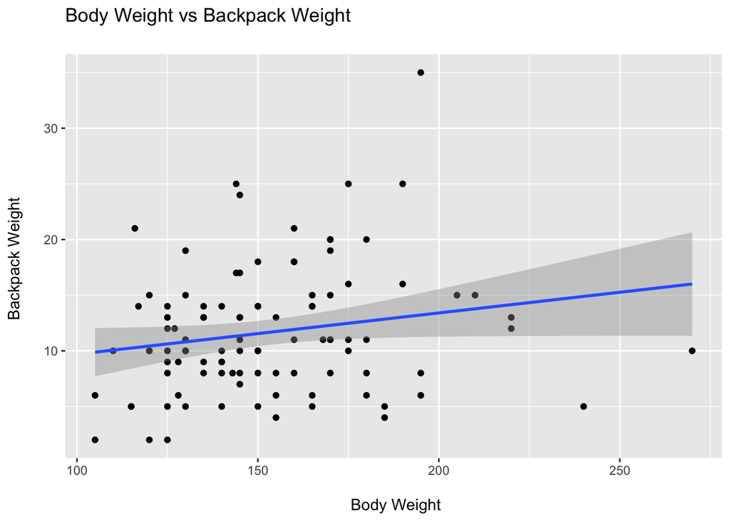

```r
ggplot(backpack_data) +
  aes(x = body_weight, y = backpack_weight) +
  geom_point() +
  geom_smooth(method = "lm") +
  labs(
    x = "\n Body Weight",
    y = "Backpack Weight \n",
    title = "Body Weight vs Backpack Weight \n"
  )
```

# Q5 - Is this relationship different between men and women? Choose an appropriate plot and interpret your findings.

- As with Q4 above, I’m not really sure if my graph is fit for purpose
- There does seem to be a relationship you might expect, that backpack weight increases with body weight, but there are a lot of outliers
- Given the subject matter, I suppose the outliers are expected: just because you physically **can** carry a heavier packpack doesn’t mean you need or want to.

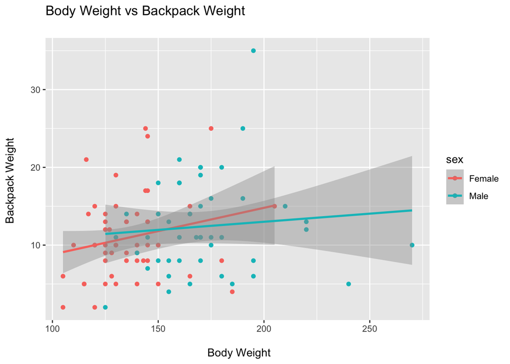

```r
ggplot(backpack_data) +
  aes(x = body_weight, y = backpack_weight, colour = sex) +
  geom_point() +
  geom_smooth(method = "lm") +
  labs(
    x = "\n Body Weight",
    y = "Backpack Weight \n",
    title = "Body Weight vs Backpack Weight \n"
  )
```

# Q6 - What proportion of students report back pain?

- Struggling to remember how to do this
- Think I need to do the calculation for total number of records, then use a command called “pull” or something similar to bring it in to use in my ratio calculation

```r
# 1st attempt
back_pain_data <- backpack_data %>%
  mutate(back_pain_text = (ifelse(back_problems == 0,
                          "No back problems",
                          "Has back problems"))) %>%
group_by(back_pain_text) %>%
summarise(number_of_students = n())
# 2nd attempt
total_students <- backpack_data %>%
  summarise(total_students = n()) %>%
pull()
```

# Q7 - Is this proportion different between men and women?

- Same problem as Q6
- Working it out manually: Only 18% of males have back problems compared to 44% of females.

```r
back_pain_data_gender <- backpack_data%>%
  mutate(back_pain_text = (ifelse(back_problems == 0,
                                  "No back problems",
                                  "Has back problems"))) %>%
group_by(sex, back_pain_text) %>%
summarise(number_of_students = n()) %>%
pivot_wider(names_from = sex, values_from = number_of_students)
```

# Q8 - Now you’ve investigated your data separately, create plots to describe the relationship between backpack weight, body weight, gender and reported backpain.

- I’m not sure how to plot this to get a view of any relationship between these variables.

## Add text description of back problems:

```r
backpack_data <- backpack_data%>%
  mutate(back_problems_text = (ifelse(back_problems == 0,
                                  "No back problems",
                                  "Has back problems")))
```

## Plot data

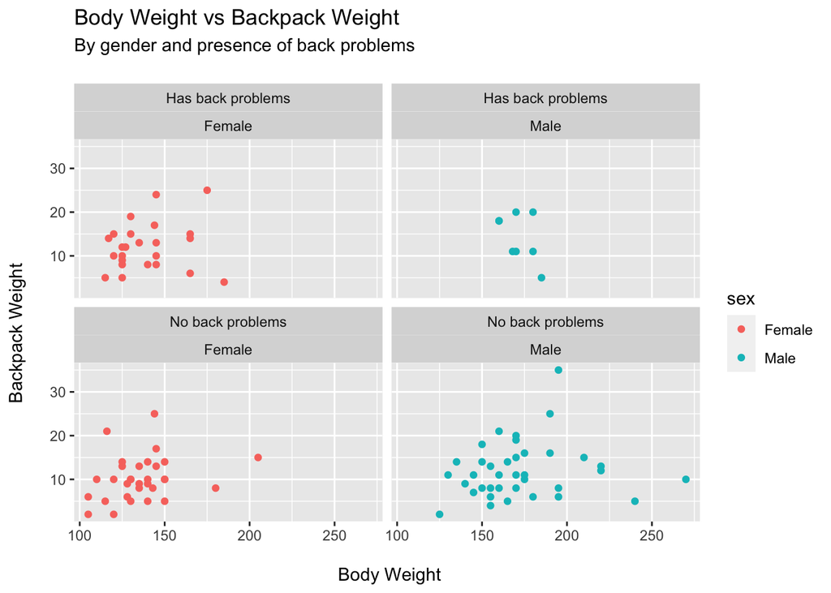

```r
ggplot(backpack_data) +
  aes(x = body_weight, y = backpack_weight, colour = sex) +
  geom_point() +
  # geom_smooth(method = "lm") +
  facet_wrap(back_problems_text ~ sex) +
  labs(
    x = "\n Body Weight",
    y = "Backpack Weight \n",
    title = "Body Weight vs Backpack Weight",
    subtitle  = "By gender and presence of back problems \n"
  )
```